# 什么决定了Formula 1的速度？

学号/Student No.：14307130391 姓名/Name：孔镜棋/Jingqi Kong Major：理论与应用力学/Mechanics

关键字: Formular 1，赛车车速，车手，车队，数据分析，数据可视化

## 导言

第二次世界大战结束后，第一届FIA世界一级方程式大奖赛（Formula 1，简称F1）于1950年在英国诞生，到今年已经有了67年的历史。超过半个世纪的历史当中，无数的车手、车队，在世界各地的赛道上刷新了一次又一次的最快圈速。随着科技和比赛规则的进化转变，F1赛车，这一代表着速度与激情的极限赛事，它的速度究竟还像以往一样令人热血沸腾么？

```python
import matplotlib
import matplotlib.pyplot as plt
import numpy as np
import pandas as pd
import seaborn as sns
```

[figure not shown]

## 1 数据获取与整理（清洗）

本文数据来源于https://www.kaggle.com/cjgdev/formula-1-race-data-19502017/data ，导入后先将数据进行清洗及整合，过程如下。

```python
#读取、整理比赛结果和赛程信息的数据
results = pd.read_csv('C:\Formula1RaceData\results.csv')
races = pd.read_csv('C:\Formula1RaceData\races.csv')
results.drop(['number','grid','positionText','positionOrder','laps','time','milliseconds','fastestLap','rank','fastestLapTime','statusId'],axis=1,inplace=True)
races.drop(['round','time','url'], axis=1, inplace=True)
races.head()
```

|  | raceId | year | circuitId | name | date |
| --- | --- | --- | --- | --- | --- |
| 0 | 1 | 2009 | 1 | Australian Grand Prix | 2009-03-29 |
| 1 | 2 | 2009 | 2 | Malaysian Grand Prix | 2009-04-05 |
| 2 | 3 | 2009 | 17 | Chinese Grand Prix | 2009-04-19 |
| 3 | 4 | 2009 | 3 | Bahrain Grand Prix | 2009-04-26 |
| 4 | 5 | 2009 | 4 | Spanish Grand Prix | 2009-05-10 |

```python
#读取、整理车手数据
drivers = pd.read_csv('C:\Formula1RaceData\drivers.csv', encoding='latin-1')
drivers.drop(['driverRef','number','forename','surname','dob','url'], axis=1, inplace=True)
drivers.head()
```

|  | driverId | code | nationality |
| --- | --- | --- | --- |
| 0 | 1 | HAM | British |
| 1 | 2 | HEI | German |
| 2 | 3 | ROS | German |
| 3 | 4 | ALO | Spanish |
| 4 | 5 | KOV | Finnish |

```python
#整合车手与比赛结果数据
dataDrivers = pd.merge(results, drivers, how = 'left', on = 'driverId')
dataDrivers.head()
```

|  | resultId | raceId | driverId | constructorId | position | points | fastestLapSpeed | code | nationality |
| --- | --- | --- | --- | --- | --- | --- | --- | --- | --- |
| 0 | 1 | 18 | 1 | 1 | 1.0 | 10.0 | 218.300 | HAM | British |
| 1 | 2 | 18 | 2 | 2 | 2.0 | 8.0 | 217.586 | HEI | German |
| 2 | 3 | 18 | 3 | 3 | 3.0 | 6.0 | 216.719 | ROS | German |
| 3 | 4 | 18 | 4 | 4 | 4.0 | 5.0 | 215.464 | ALO | Spanish |
| 4 | 5 | 18 | 5 | 1 | 5.0 | 4.0 | 218.385 | KOV | Finnish |

```python
#整合车手、比赛结果、赛程信息的数据
dataResults = pd.merge(dataDrivers, races, how = 'left', on='raceId')
dataResults.head()
```

|  | resultId | raceId | driverId | constructorId | position | points | fastestLapSpeed | code | nationality | year | circuitId | name | date |
| --- | --- | --- | --- | --- | --- | --- | --- | --- | --- | --- | --- | --- | --- |
| 0 | 1 | 18 | 1 | 1 | 1.0 | 10.0 | 218.300 | HAM | British | 2008 | 1 | Australian Grand Prix | 2008-03-16 |
| 1 | 2 | 18 | 2 | 2 | 2.0 | 8.0 | 217.586 | HEI | German | 2008 | 1 | Australian Grand Prix | 2008-03-16 |
| 2 | 3 | 18 | 3 | 3 | 3.0 | 6.0 | 216.719 | ROS | German | 2008 | 1 | Australian Grand Prix | 2008-03-16 |
| 3 | 4 | 18 | 4 | 4 | 4.0 | 5.0 | 215.464 | ALO | Spanish | 2008 | 1 | Australian Grand Prix | 2008-03-16 |
| 4 | 5 | 18 | 5 | 1 | 5.0 | 4.0 | 218.385 | KOV | Finnish | 2008 | 1 | Australian Grand Prix | 2008-03-16 |

## 2 数据分析

### 2.1 2005-2017赛季F1赛车的速度趋势

2005赛季之前的比赛，由于赛中监测系统设施还不够完善，缺少关于实时车速等相关信息，故筛选出2005赛季之后的比赛信息用以分析。另外说明：在之后分析中用到的关于赛车速度的概念，都是指每位车手每场比赛中作出的最快圈的速度。

```python
#筛选出05-17赛季的数据，并计算期间每场比赛的平均最快圈速度
dataResults_0517 = dataResults[dataResults["year"]>2004]
dataResults_0517 = dataResults_0517['fastestLapSpeed'].groupby(dataResults_0517['raceId']).mean()
dataFLS_0517 = dataResults_0517.reset_index()
dataFLS_0517.head()
```

|  | raceId | fastestLapSpeed |
| --- | --- | --- |
| 0 | 1 | 214.918895 |
| 1 | 2 | 202.320556 |
| 2 | 3 | 171.060450 |
| 3 | 4 | 204.150650 |
| 4 | 5 | 199.641562 |

```python
dataRaces_0517 = races[(races["year"]>2004) & (races["year"]<2018)]
dataRaces_0517.head()
```

|  | raceId | year | circuitId | name | date |
| --- | --- | --- | --- | --- | --- |
| 0 | 1 | 2009 | 1 | Australian Grand Prix | 2009-03-29 |
| 1 | 2 | 2009 | 2 | Malaysian Grand Prix | 2009-04-05 |
| 2 | 3 | 2009 | 17 | Chinese Grand Prix | 2009-04-19 |
| 3 | 4 | 2009 | 3 | Bahrain Grand Prix | 2009-04-26 |
| 4 | 5 | 2009 | 4 | Spanish Grand Prix | 2009-05-10 |

```python
dataFLS_0517 = pd.merge(dataFLS_0517, dataRaces_0517, how = 'left', on='raceId')
dataFLS_0517.head()
```

|  | raceId | fastestLapSpeed | year | circuitId | name | date |
| --- | --- | --- | --- | --- | --- | --- |
| 0 | 1 | 214.918895 | 2009 | 1 | Australian Grand Prix | 2009-03-29 |
| 1 | 2 | 202.320556 | 2009 | 2 | Malaysian Grand Prix | 2009-04-05 |
| 2 | 3 | 171.060450 | 2009 | 17 | Chinese Grand Prix | 2009-04-19 |
| 3 | 4 | 204.150650 | 2009 | 3 | Bahrain Grand Prix | 2009-04-26 |
| 4 | 5 | 199.641562 | 2009 | 4 | Spanish Grand Prix | 2009-05-10 |

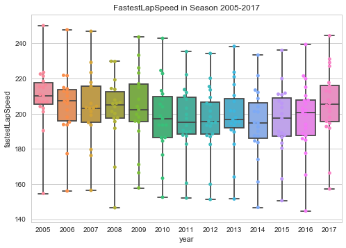

```python
sns.set_style("whitegrid")
sns.set_palette("Set2")
sns.boxplot(x="year", y="fastestLapSpeed", data = dataFLS_0517, whis=np.inf)
sns.swarmplot(x="year", y="fastestLapSpeed", data = dataFLS_0517)
plt.title('FastestLapSpeed in Season 2005-2017')
plt.show()
```

上图用散点图和箱线图组合的方式，展示了从2005赛季至2017赛季，每场比赛中的所有车手作出的最快圈速的平均数。从该图我们可以看出，2005赛季到2017赛季各个比赛中的最快圈速中位数基本在200km/h左右浮动，说明在这段时间内F1车速整体较为稳定，但有下降趋势。对比每个赛季中最快圈速的四分位数间距，发现也基本相似。这说明，在同一个赛季中，每场比赛的车速也基本一致。

```python
#删除无效数据较多的比赛场地
dataFLS_0517_ByCircuit = dataFLS_0517[~dataFLS_0517.name.isin(['Azerbaijan Grand Prix','Mexican Grand Prix','Russian Grand Prix','Austrian Grand Prix','Korean Grand Prix','Indian Grand Prix','French Grand Prix','United States Grand Prix','San Marino Grand Prix','Turkish Grand Prix','European Grand Prix'])]
dataFLS_0517_ByCircuit.head()
```

|  | raceId | fastestLapSpeed | year | circuitId | name | date |
| --- | --- | --- | --- | --- | --- | --- |
| 0 | 1 | 214.918895 | 2009 | 1 | Australian Grand Prix | 2009-03-29 |
| 1 | 2 | 202.320556 | 2009 | 2 | Malaysian Grand Prix | 2009-04-05 |
| 2 | 3 | 171.060450 | 2009 | 17 | Chinese Grand Prix | 2009-04-19 |
| 3 | 4 | 204.150650 | 2009 | 3 | Bahrain Grand Prix | 2009-04-26 |
| 4 | 5 | 199.641562 | 2009 | 4 | Spanish Grand Prix | 2009-05-10 |

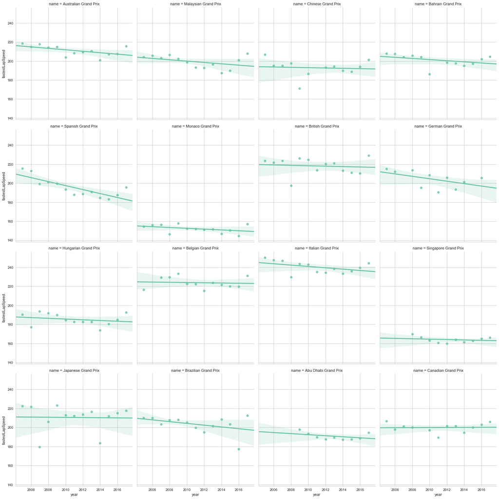

```python
#按赛场分子图，分别绘制赛季与平均最快圈速的一元回归曲线
sns.set_style("whitegrid")
sns.lmplot(x="year", y="fastestLapSpeed", col="name", data=dataFLS_0517_ByCircuit, col_wrap=4)
plt.show()
```

由于上图中线性拟合的结果不尽人意，下面采用二次曲线再进行一次拟合，以获得更好的结果。

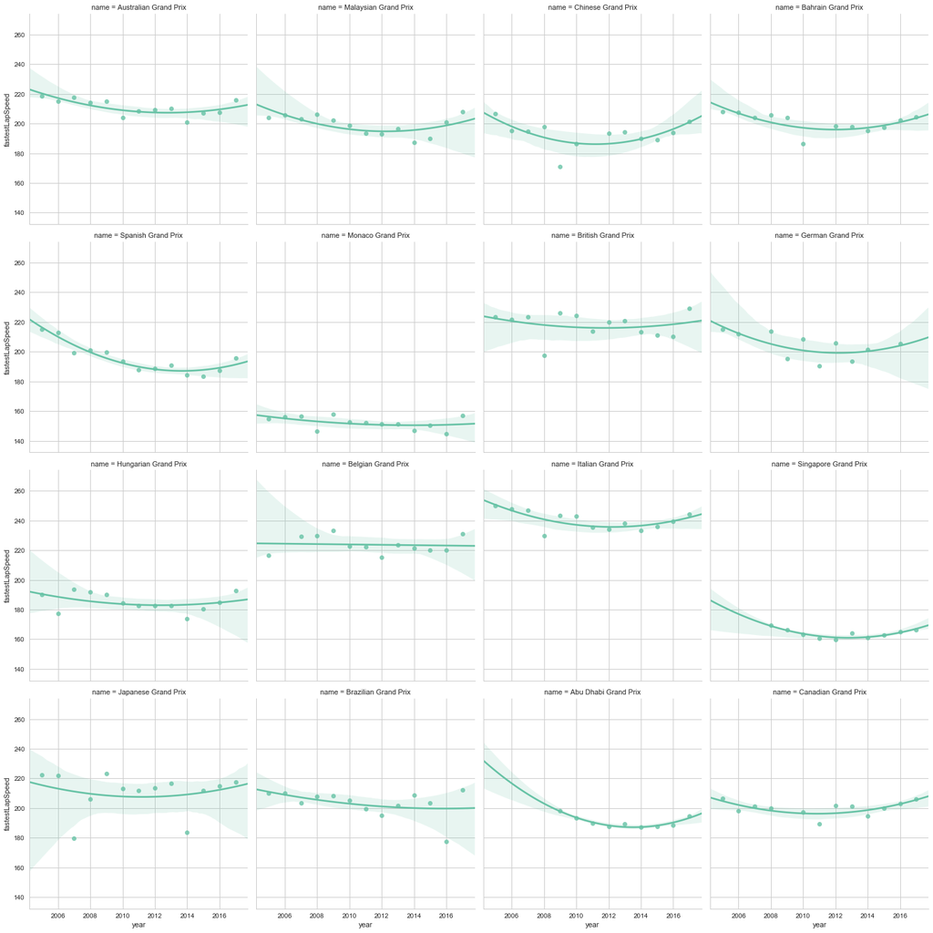

```python
#按赛场分子图，分别绘制赛季与平均最快圈速的二元回归曲线
sns.set_style("whitegrid")
sns.lmplot(x="year", y="fastestLapSpeed", col="name", data = dataFLS_0517_ByCircuit, col_wrap=4, order=2)
plt.show()
```

经过二次拟合，如上图所示，大部分的赛场都得到了很好的拟合结果。观察得出2012-2014赛季是一个拐点，在此之前F1车速呈下降趋势，而在此之后F1车速有所回升。在接下来的内容中，将主要就：引擎因素、空气动力学因素、赛道特性因素来分析这一速度变化情况。

#### 2.1.1 原因一：引擎的因素

根据FIA（国际汽联）的规定，每个赛季车队在设计新一型号的赛车时，都需要以大赛规则为准。在FIA制定的规则中，对引擎的限制是影响F1赛车车速的主要因素之一。 下表简单总结了从1950到2017年9次主要的引擎规则特点[2]：

| 年代 | 排气量 | 吸气形式 | 最大马力 |
| --- | --- | --- | --- |
| 1950-1953 | 4.5L/1.5L | 自然/机械增压 | 425 |
| 1954-1960 | 2.5L/0.75L | 自然/机械增压 | 290 |
| 1961-1965 | 1.5L | 自然吸气 | 225 |
| 1966-1986 | 3.0L/1.5L | 自然/涡轮增压 | 1350 |
| 1987-1988 | 3.5L/1.5L | 自吸/涡轮增压 | 690 |
| 1989-1994 | 3.5L | 自然吸气 | 820 |
| 1995-2005 | 3.0L | 自然吸气 | 930 |
| 2006-2013 | 2.4L | 自然吸气 | 740 |
| 2014-2020 | 1.6L | 混动涡轮增压 | 1000 |

除了对引擎本身的限制，引擎在比赛中的使用规则也有明确要求：在2004年的冠军赛中，引擎需要持续一个完整的比赛周末。在2005年的比赛中，他们被要求在比赛的两个周末进行比赛，如果一个队伍在两场比赛之间换了一个发动机，他们将被罚10个积分。在2008赛季，引擎需要持续两个正式比赛周。然而，在2009赛季，每位车手都可以在本赛季使用最多8台发动机，这意味着几台发动机必须持续3个比赛周。这种限制发动机使用的方法也增加了战术的重要性，车队需要做出决策怎样在整个赛季中使引擎的使用最优化，这也直接导致了这台赛车在赛场上的全方位表现。

[figure not shown]

总体来说一直在退步的排气量和马力，是2014赛季之前F1速度变慢的一个主要原因。但在2014赛季这一节点上，引入混合动力单元，引擎设计变得复杂的同时，也获得了更多的动力，直接导致F1的赛车速度有所回升。2017年10月31日，FIA与各引擎厂商和车队的会议上暂拟了未来的引擎规则方向，增大声浪、削减开发经费、维持小排气量混动结构成为了的三个核心。未来的引擎将会如何发展，又会对F1赛车有怎样的影响作用，让人期待。

#### 2.1.2 原因二：空气动力学因素

空气动力学已经成为F1这项运动成功的关键，每年在这个领域的研究和开发团队花费数千万美元。空气动力学设计师有两个主要关注点：创造下压力，帮助推动赛车的轮胎进入赛道并提高转弯力量; 并最大限度地减少由湍流引起的阻力。现代一级方程式赛车的每一个表面，从悬挂连接到车手头盔的形状，都考虑到其空气动力学效应。气流从人体内“分离”，造成空气紊乱，从而产生阻力，从而减慢汽车的速度。

在这里值得我们关注的是，自从2011赛季开始以来，赛车已经被允许可以采用可调整的后翼，也就是DRS（减阻系统）。这是一种能够解决空气紊流问题的系统。在赛道的直道上，车手可以部署DRS，从而打开后翼，减少汽车的阻力，使其更快地移动。一旦车手接触刹车，后翼再次关闭。

当然，随着科技的进步，各个车队对空气动力学有了更深入的研究，可以更好的设计赛车的气动外形。在变幻莫测的赛道上，优良的气动外形和气动效率无疑是主导赛车速度表现的一大因素。

#### 2.1.3 原因三：赛道差异因素

在之前的速度趋势图中，我们可以明显的观察到各个赛道之间的差异。为了分析其中缘由，在这里挑选出三条具有代表性的赛道，分析它们的赛道特性和赛车车速之间的联系。

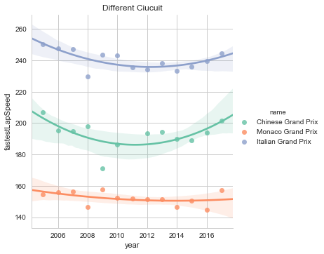

```python
#选取三条有代表性的赛道数据
dataFLS_0517_PartCircuit = dataFLS_0517_ByCircuit[dataFLS_0517_ByCircuit.name.isin(['Chinese Grand Prix','Monaco Grand Prix','Italian Grand Prix'])]
sns.lmplot(x="year", y="fastestLapSpeed", hue="name", data = dataFLS_0517_PartCircuit, order=2)
plt.title('Different Ciucuit')
plt.show()
```

这里选取的三条赛道分别是：中国上海赛道、摩纳哥蒙特卡洛赛道、意大利蒙扎赛道。首先，分别介绍一下这三条赛道的基本信息。[4]

- 中国上海赛道：由著名的德国赛道设计师赫曼·蒂尔克设计，其设计来自中文的“上”字。每圈长度为5.45124公里，平均时速205公里。正式比赛共五十六圈，全长305.066公里。现最快圈速由迈克尔·舒马赫创造，为1分32秒238。
- 摩纳哥蒙特卡洛赛道——最短、最难：是摩纳哥公国的一条街道赛道。由于赛程只有3.340公里，所以也成为了圈数最多的赛道。这条狭窄的赛道充满了各种窄弯和高低落差，被一些人认为是F1比赛中最有挑战性的赛道。这里有F1中最慢的弯角，也有能以260公里/小时通过的高速弯。
- 意大利蒙扎赛道——最快、最老：修建于1922年，是世界上最早被正式启用的F1赛道，位于意大利米兰北部的蒙扎市，这里一直是意大利F1比赛的主办地。由于拥有超长的直道，赛车在蒙扎赛道上更容易表现加速性能，平均时速几乎达到250公里，最高速度更高达350公里，至今还保持着F1平均时速的最高记录。

这三条赛道由于其本身的布局不同，所以简化归类为中速赛道、低速赛道和高速赛道。上面的二次回归曲线图可以说明赛道特性对于赛车速度的影响。其中，摩纳哥赛道的速度变化趋势最小，这是因为摩纳哥赛道有较多的窄弯，高速段很少，这极大限制了赛车在比赛过程中的速度，所以赛车性能本身所能达到的速度在这里并无法发挥出来。接下来观察意大利蒙扎赛道的数据，其速度在三者中最大，因为这条赛道，多是高速直道，少弯角，在这里赛车可以将其速度推到极致。最后，上海赛场做为中速赛道的同时，相比于其他赛道有更多的特别的弯角，这增加了赛车在比赛中的多变因素，使得其数据较为离散。

综合以上，我们可以得出赛道特性对于车速的影响很大。除了在以上分析中，关于赛道本身构造引发的速度差异，还有赛道所在位置的气候、赛道的新旧条件有带作为其影响因素，进行更深一步的分析。

### 2.2 探究车手对车速的影响

在分析完2005赛季以来F1赛车速度的总体走向后，我有了一个新的疑问——车手对一辆赛车的速度有多大影响？也就是说，假设同一个车队的两位车手，他们在每个赛季的所使用的赛车配置基本相同、调教合理的情况下，车手本身的驾驶能力和驾驶技术，对赛车性能的发挥影响有多大？ 在这一疑问的基础上，我们可以筛选出在几个赛季内同一车队不同车手的比赛结果：

#### 2.2.1 2015-2017赛季Ferrari车手：Sebastian Vettel & Kimi Räikkönen

在这里，我们筛选出2015-2017赛季，Ferrari车队的两位车手的数据，绘制小提琴图用以观察他们的表现。

```python
#筛选出15-17赛季，Ferrari车队两位车手的比赛数据
dataResults_1517 = dataResults[dataResults["year"]>2014]
dataDriver_Ferrari = dataResults_1517[dataResults_1517.code.isin(['VET','RAI'])]
dataDriver_Ferrari.head()
```

|  | resultId | raceId | driverId | constructorId | position | points | fastestLapSpeed | code | nationality | year | circuitId | name | date |
| --- | --- | --- | --- | --- | --- | --- | --- | --- | --- | --- | --- | --- | --- |
| 22536 | 22540 | 926 | 20 | 6 | 3.0 | 15.0 | 208.740 | VET | German | 2015 | 1 | Australian Grand Prix | 2015-03-15 |
| 22545 | 22549 | 926 | 8 | 6 | NaN | 0.0 | 208.811 | RAI | Finnish | 2015 | 1 | Australian Grand Prix | 2015-03-15 |
| 22552 | 22556 | 927 | 20 | 6 | 1.0 | 25.0 | 193.501 | VET | German | 2015 | 2 | Malaysian Grand Prix | 2015-03-29 |
| 22555 | 22559 | 927 | 8 | 6 | 4.0 | 12.0 | 191.644 | RAI | Finnish | 2015 | 2 | Malaysian Grand Prix | 2015-03-29 |
| 22574 | 22578 | 928 | 20 | 6 | 3.0 | 15.0 | 190.487 | VET | German | 2015 | 17 | Chinese Grand Prix | 2015-04-12 |

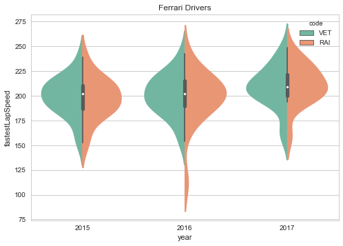

```python
#绘制Ferrari车手的小提琴图
sns.set_style("whitegrid")
sns.set_palette("Set2")
sns.violinplot(x="year", y="fastestLapSpeed", hue="code", data=dataDriver_Ferrari, split=True)
plt.title('Ferrari Drivers')
plt.show()
```

根据Ferrari车队两位车手数据的小提琴图观察得出，两位车手在这三个赛季中车速表现基本一致，一个赛季中每场比赛的最快圈速度分布较为集中。特别的是，在2016赛季Raikkonen的车速数据有一些较低的离散值，这说明该车手在本赛季的表现很不稳定，可能出现过多次赛车故障的情况。

#### 2.2.1 2013-2016赛季Mercedes车手：Lewis Hamilton & Nico Rosberg

同上述过程，筛选出2013-2016赛季，Mercedes车队的两位车手的数据，绘制小提琴图用以观察他们的表现。

```python
#选出13-16赛季，Mercedes车队两位车手的比赛数据
dataResults_1316 = dataResults[(dataResults["year"]>2012) & (dataResults["year"]<2017)]
dataDriver_Mercedes = dataResults_1316[dataResults_1316.code.isin(['ROS','HAM'])]
dataDriver_Mercedes.head()
```

|  | resultId | raceId | driverId | constructorId | position | points | fastestLapSpeed | code | nationality | year | circuitId | name | date |
| --- | --- | --- | --- | --- | --- | --- | --- | --- | --- | --- | --- | --- | --- |
| 21713 | 21716 | 880 | 1 | 131 | 5.0 | 10.0 | 212.689 | HAM | British | 2013 | 1 | Australian Grand Prix | 2013-03-17 |
| 21728 | 21731 | 880 | 3 | 131 | NaN | 0.0 | 206.926 | ROS | German | 2013 | 1 | Australian Grand Prix | 2013-03-17 |
| 21733 | 21736 | 881 | 1 | 131 | 3.0 | 15.0 | 197.570 | HAM | British | 2013 | 2 | Malaysian Grand Prix | 2013-03-24 |
| 21734 | 21737 | 881 | 3 | 131 | 4.0 | 12.0 | 198.052 | ROS | German | 2013 | 2 | Malaysian Grand Prix | 2013-03-24 |
| 21755 | 21758 | 882 | 1 | 131 | 3.0 | 15.0 | 196.273 | HAM | British | 2013 | 17 | Chinese Grand Prix | 2013-04-14 |

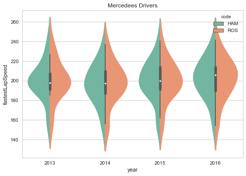

```python
#绘制Mercedes车队两位车手数据的小提琴图
sns.set_style("whitegrid")
sns.set_palette("Set2")
sns.violinplot(x="year", y="fastestLapSpeed", hue="code", data=dataDriver_Mercedes,  split=True)
plt.title('Mercedees Drivers')
plt.show()
```

#### 2.2.1 2009-2012赛季Red Bull车手：Mark Webber & Sebastian Vettel

同上述过程，筛选出2009-2012赛季，Red Bull车队的两位车手的数据，绘制小提琴图用以观察他们的表现。

```python
#选出09-12赛季，RedBull车队两位车手的比赛数据
dataResults_0912 = dataResults[(dataResults["year"]>2008) & (dataResults["year"]<2013)]
dataDriver_RedBull = dataResults_0912[dataResults_0912.code.isin(['VET','WEB'])]
dataDriver_RedBull.head()
```

|  | resultId | raceId | driverId | constructorId | position | points | fastestLapSpeed | code | nationality | year | circuitId | name | date |
| --- | --- | --- | --- | --- | --- | --- | --- | --- | --- | --- | --- | --- | --- |
| 7564 | 7565 | 1 | 17 | 9 | 12.0 | 0.0 | 215.695 | WEB | Australian | 2009 | 1 | Australian Grand Prix | 2009-03-29 |
| 7565 | 7566 | 1 | 20 | 9 | 13.0 | 0.0 | 216.596 | VET | German | 2009 | 1 | Australian Grand Prix | 2009-03-29 |
| 7578 | 7579 | 2 | 17 | 9 | 6.0 | 1.5 | 204.304 | WEB | Australian | 2009 | 2 | Malaysian Grand Prix | 2009-04-05 |
| 7587 | 7588 | 2 | 20 | 9 | 15.0 | 0.0 | 202.737 | VET | German | 2009 | 2 | Malaysian Grand Prix | 2009-04-05 |
| 7593 | 7594 | 3 | 20 | 9 | 1.0 | 10.0 | 174.235 | VET | German | 2009 | 17 | Chinese Grand Prix | 2009-04-19 |

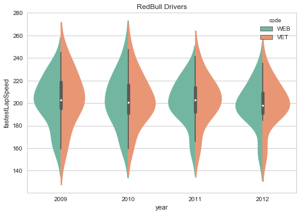

```python
sns.set_style("whitegrid")
sns.set_palette("Set2")
sns.violinplot(x="year", y="fastestLapSpeed", hue="code", data=dataDriver_RedBull,  split=True)
plt.title('RedBull Drivers')
plt.show()
```

综合以上对三个车队车手的相对分析，我们可以基本得出这样的结论：在F1赛场上，车手的技术对速度的决定性很小，换句话说，一辆F1赛车在比赛中所能推进的速度与车手本身的驾驶风格无关或关系很小。

### 2.3 车队对车速的影响

在前一部分中分析了车手对车速的影响程度，而在这一部分中，我将就车队对赛车速度的影响展开分析。首先挑选2005-2017赛季中五个主要的参赛车队，分别是：法拉利（Ferrari）、印度力量（Force India）、迈凯轮（Mclaren）、梅赛德斯（Mercedes）和红牛（Red Bull）。在此基础上，求出每个赛季各个车队在车速上的均值，并绘制线型图用以观察。

```python
#读取并整理车队数据
constructors = pd.read_csv('/Users/liumt/Documents/FinalReport/Formula1RaceData/constructors.csv')
constructors.drop(['nationality','constructorRef','url','Unnamed: 5'], axis=1, inplace=True)
constructors.columns = ['constructorId', 'teamName']
constructors.head()
```

|  | constructorId | teamName |
| --- | --- | --- |
| 0 | 1 | McLaren |
| 1 | 2 | BMW Sauber |
| 2 | 3 | Williams |
| 3 | 4 | Renault |
| 4 | 5 | Toro Rosso |

```python
#读取并整理车队参赛数据
constructorResults = pd.read_csv('/Users/liumt/Documents/FinalReport/Formula1RaceData/constructorResults.csv')
constructorResults.drop(['constructorResultsId','status'], axis=1, inplace=True)
constructorResults.columns = ['raceId', 'constructorId', 'teamPoints']
constructorResults.head()
```

|  | raceId | constructorId | teamPoints |
| --- | --- | --- | --- |
| 0 | 18 | 1 | 14.0 |
| 1 | 18 | 2 | 8.0 |
| 2 | 18 | 3 | 9.0 |
| 3 | 18 | 4 | 5.0 |
| 4 | 18 | 5 | 2.0 |

```python
#整合车队及其参赛数据
dataConstructors = pd.merge(constructorResults, constructors, how = 'left', on='constructorId')
dataConstructors.head()
```

|  | raceId | constructorId | teamPoints | teamName |
| --- | --- | --- | --- | --- |
| 0 | 18 | 1 | 14.0 | McLaren |
| 1 | 18 | 2 | 8.0 | BMW Sauber |
| 2 | 18 | 3 | 9.0 | Williams |
| 3 | 18 | 4 | 5.0 | Renault |
| 4 | 18 | 5 | 2.0 | Toro Rosso |

```python
#整合车队参赛数据和赛程数据
dataResults_All = pd.merge(dataResults, dataConstructors, how = 'inner', on=['raceId','constructorId'])
dataResults_All.head()
```

|  | resultId | raceId | driverId | constructorId | position | points | fastestLapSpeed | code | nationality | year | circuitId | name | date | teamPoints | teamName |
| --- | --- | --- | --- | --- | --- | --- | --- | --- | --- | --- | --- | --- | --- | --- | --- |
| 0 | 1 | 18 | 1 | 1 | 1.0 | 10.0 | 218.300 | HAM | British | 2008 | 1 | Australian Grand Prix | 2008-03-16 | 14.0 | McLaren |
| 1 | 5 | 18 | 5 | 1 | 5.0 | 4.0 | 218.385 | KOV | Finnish | 2008 | 1 | Australian Grand Prix | 2008-03-16 | 14.0 | McLaren |
| 2 | 2 | 18 | 2 | 2 | 2.0 | 8.0 | 217.586 | HEI | German | 2008 | 1 | Australian Grand Prix | 2008-03-16 | 8.0 | BMW Sauber |
| 3 | 9 | 18 | 9 | 2 | NaN | 0.0 | 215.100 | KUB | Polish | 2008 | 1 | Australian Grand Prix | 2008-03-16 | 8.0 | BMW Sauber |
| 4 | 3 | 18 | 3 | 3 | 3.0 | 6.0 | 216.719 | ROS | German | 2008 | 1 | Australian Grand Prix | 2008-03-16 | 9.0 | Williams |

```python
#筛选出15-17赛季的数据
dataResults_All_0517 = dataResults_All[dataResults_All["year"]>2004]
dataResults_All_0517 = dataResults_All_0517.groupby(['year','constructorId'])['fastestLapSpeed'].mean()
dataFLS_byContructors = dataResults_All_0517.reset_index()
dataFLS_byContructors = pd.merge(dataFLS_byContructors, constructors, how = 'left', on='constructorId')
dataFLS_byContructors.head()
```

|  | year | constructorId | fastestLapSpeed | teamName |
| --- | --- | --- | --- | --- |
| 0 | 2005 | 1 | 213.284943 | McLaren |
| 1 | 2005 | 3 | 211.035088 | Williams |
| 2 | 2005 | 4 | 212.342611 | Renault |
| 3 | 2005 | 6 | 211.518026 | Ferrari |
| 4 | 2005 | 7 | 211.517395 | Toyota |

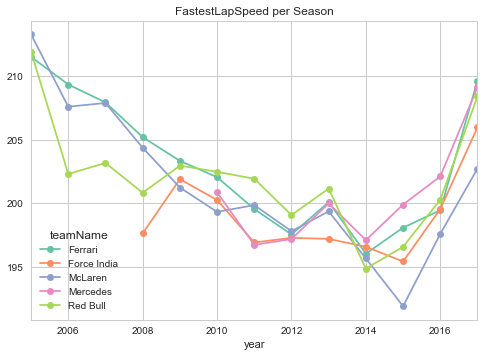

```python
#挑选出主要的五个车队，进行点线图绘制
dataFLS_byContructors = dataFLS_byContructors[dataFLS_byContructors.teamName.isin(['McLaren','Ferrari','Red Bull','Force India','Renalt','Mercedes'])]
sns.set_palette("Set2")
sns.set_style("whitegrid")
dataFLS_byContructors.pivot(index='year',columns='teamName',values='fastestLapSpeed',).plot(title='FastestLapSpeed per Season',style='-o')
plt.show()
```

根据上图可以看出，在2005-2017赛季中，这五个车队的速度走势趋于一致。但同时，车队间的速度表现上还是有一定的差距，比如2006赛季红牛车队远不如法拉利和迈凯轮的表现，但在2015赛季，迈凯轮却成为了中队车队中的落跑者。这说明了车队的表现在影响赛车速度上有着很大的作用。

### 2.4 车手积分、车队积分与车速

在这部分中，我试图探索车手积分、车队积分与赛车速之间的联系。这里简要介绍一下F1赛车的积分制度：F1的年度总冠军分为两种，车手总冠军及车队总冠军。计分方式是采用积分制，车手与车队的积分都是累积的。车队积分则以两位车手积分累加。

在这里我选取了三位公认驾驶技术优秀的车手：Lewis Hamilton，Sebastian Vettel，Fernando Alonso，他们分别来自不同的车队。在筛选出他们每站比赛的积分、他们所在车队每站比赛的积分和他们在该站比赛中所作出的最快圈速度后，绘制变量关系图进行分析。

```python
#筛选出三位车手每站比赛的积分、所在车队的积分、最快圈速度
dataResults_17_Points = dataResults_All[dataResults_All["year"]>2014]
dataResults_17_Points = dataResults_17_Points[dataResults_17_Points.code.isin(['VET','HAM','ALO'])]
dataResults_17_Points.drop(['resultId','raceId','driverId','constructorId','position','nationality','year','circuitId','name','date','teamName'],axis=1,inplace=True)
dataResults_17_Points.head()
```

|  | points | fastestLapSpeed | code | teamPoints |
| --- | --- | --- | --- | --- |
| 20967 | 25.0 | 209.915 | HAM | 43.0 |
| 20969 | 15.0 | 208.740 | VET | 15.0 |
| 20985 | 25.0 | 193.501 | VET | 37.0 |
| 20987 | 18.0 | 193.501 | HAM | 33.0 |
| 21004 | 0.0 | 183.983 | ALO | 0.0 |

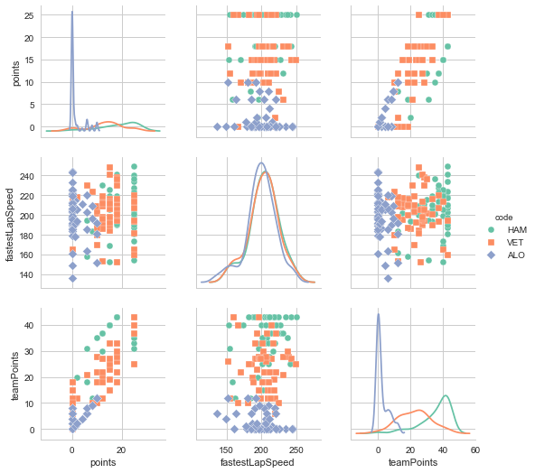

```python
#绘制变量关系图
np.seterr(divide='ignore', invalid='ignore')
sns.set_palette("Set2")
sns.pairplot(dataResults_17_Points, hue="code", diag_kind='kde', markers=["o", "s", "D"])
plt.show()
```

其次，观察车手积分（points）与车手最快圈速度（fastestLapSpeed）的关系图，观察可得选手在该站比赛所能做出的速度与他是否能获得积分并无直接联系。这意味着，尽管一个车手在比赛中的速度表现很优异，但他也可能最后一分也拿不到。这是因为在比赛中，速度只是取得好成绩的必要条件，而非充分条件，左右着比赛的还有车队战术等等其他因素。

最后，观察车手最快圈速度（fastestLapSpeed）与车队积分（teamPoints）的关系图，这与车手积分和车速相似，并无显著的关系，这同样是因为比赛中许多其他的影响因素所导致。

## 参考文献

[1]数据来源 [Link](https://www.kaggle.com/jonathanbouchet/f1-data-analysis/data)

[2]搜狐汽车.67年来，一直在“退步”的F1引擎.http://m.sohu.com/a/205038312_674842 ，2017-11-17

[3]wikipedia.Formular 1.https://en.wikipedia.org/wiki/Formula_One ，2018-1-3

[4]张璋.聊聊你不知道的事F1经典赛道十宗“最”.http://race.fblife.com/html/20161104/178453.html ，2016-11-4